# PlotMicrobiome analysis with AI report

## PlotMicrobiome analysis report with AI assistance

The analysis of microbiome data was performed with PlotMicrobiome (https://github.com/ssun6/plotmicrobiome).

The interpretation of the data was generated with AI models deepseek-r1.

AI can make mistakes, please review all interpretations and conclusions critically before drawing scientific inferences.

### PCoA analysis by rural_urban_status

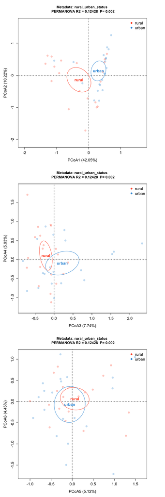

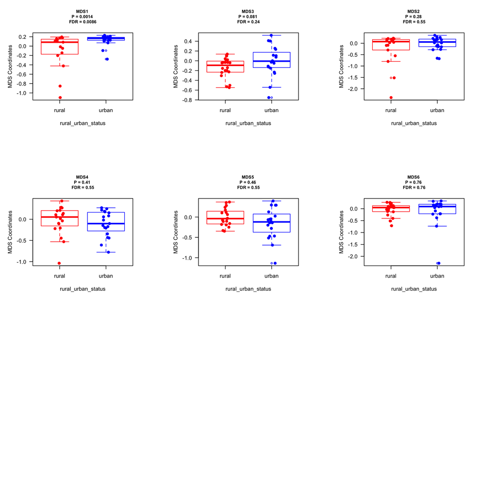